# report

Xinyu Shen xs2384

2019/12/7

```r
lawsuit =
read_csv("data/Lawsuit.csv") %>%
   janitor::clean_names() %>%
  mutate(dept = factor(dept,levels = c(1:6),
                       labels =
                    c("Biochemistry","Physiology","Genetics",
                      "Pediatrics","Medicine","Surgery")),
         gender = factor(gender,levels = c(0:1),
                       labels =
                    c("Female","Male")),
         clin = factor(clin,levels = c(0:1),
                       labels =
                    c("Research","Clinical")),
         cert = factor(cert,levels = c(0:1),
                       labels =
                    c("Not certified","Broad certified")),
         rank = factor(rank,levels = c(1:3),
                       labels =
                    c("Assistant","Associate","Full professor")),
         sal_avg = (sal94 + sal95)/2) %>% dplyr::select(-sal94, -sal95)
```

Summarize all variables by gender

```r
 sum_data  <-  arsenal::tableby( gender ~ dept + clin + cert +
                                 prate + exper + rank + sal_avg,
                                data  = lawsuit,
                                test  = FALSE,
                                total = FALSE,
                                numeric.stats =
                                  c("meansd","medianq1q3","range"))
summ = summary(sum_data,text = TRUE)
summ
```

```
##
##
## |                   |           Female (N=106)           |            Male (N=155)             |
## |:------------------|:----------------------------------:|:-----------------------------------:|
## |dept               |                                    |                                     |
## |-  Biochemistry    |             20 (18.9%)             |             30 (19.4%)              |
## |-  Physiology      |             20 (18.9%)             |             20 (12.9%)              |
## |-  Genetics        |             11 (10.4%)             |              10 (6.5%)              |
## |-  Pediatrics      |             20 (18.9%)             |              10 (6.5%)              |
## |-  Medicine        |             30 (28.3%)             |             50 (32.3%)              |
## |-  Surgery         |              5 (4.7%)              |             35 (22.6%)              |
## |clin               |                                    |                                     |
## |-  Research        |             46 (43.4%)             |             55 (35.5%)              |
## |-  Clinical        |             60 (56.6%)             |             100 (64.5%)             |
## |cert               |                                    |                                     |
## |-  Not certified   |             36 (34.0%)             |             37 (23.9%)              |
## |-  Broad certified |             70 (66.0%)             |             118 (76.1%)             |
## |prate              |                                    |                                     |
## |-  Mean (SD)       |           5.350 (1.886)            |            4.646 (1.938)            |
## |-  Median (Q1, Q3) |        5.250 (3.725, 7.275)        |        4.000 (3.100, 6.700)         |
## |-  Range           |           2.400 - 8.700            |            1.300 - 8.600            |
## |exper              |                                    |                                     |
## |-  Mean (SD)       |           7.491 (4.166)            |           12.103 (6.704)            |
## |-  Median (Q1, Q3) |       7.000 (5.000, 10.000)        |       10.000 (7.000, 15.000)        |
## |-  Range           |           1.000 - 23.000           |           2.000 - 37.000            |
## |rank               |                                    |                                     |
## |-  Assistant       |             69 (65.1%)             |             43 (27.7%)              |
## |-  Associate       |             21 (19.8%)             |             43 (27.7%)              |
## |-  Full professor  |             16 (15.1%)             |             69 (44.5%)              |
## |sal_avg            |                                    |                                     |
## |-  Mean (SD)       |       124874.094 (59089.620)       |       186126.426 (90397.109)        |
## |-  Median (Q1, Q3) | 113706.000 (79059.875, 148401.125) | 162987.000 (114612.500, 244332.250) |
## |-  Range           |       36594.500 - 323872.500       |       55752.500 - 445859.000        |
```

Distributions

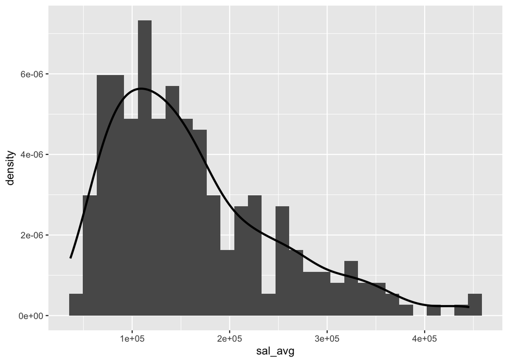

```r
lawsuit %>%
 ggplot(aes(sal_avg,..density..))+
 geom_histogram()+
 geom_line(stat = 'density',size = 1)+
    labs(x = "sal_avg")
```

The distribution for outcome is right skew. So we may want to try the log transformation.

Possible transformation

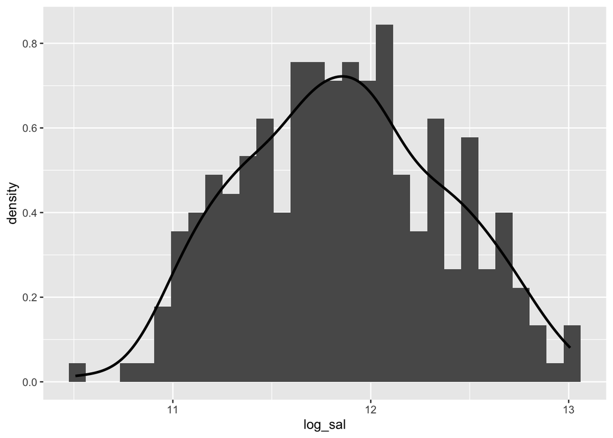

```r
lawsuit_log = lawsuit %>% mutate(
        log_sal = log(sal_avg)) %>% dplyr::select(-id, -sal_avg)
lawsuit_log %>%
 ggplot(aes(log_sal,..density..))+
 geom_histogram()+
 geom_line(stat = 'density',size = 1)+
    labs(x = "log_sal")
```

After using log transformation, the outcome almost follow a normal distribution.

# Confounders

## Confounders

```r
con = lm(log_sal ~ gender, data = lawsuit_log) %>% summary()
con_1 = lm(log_sal ~ gender + dept, data = lawsuit_log) %>% summary()
con_2 = lm(log_sal ~ gender + clin, data = lawsuit_log) %>% summary()
con_3 = lm(log_sal ~ gender + cert, data = lawsuit_log) %>% summary()
con_4 = lm(log_sal ~ gender + prate, data = lawsuit_log) %>% summary()
con_5 = lm(log_sal ~ gender + exper, data = lawsuit_log) %>% summary()
con_6 = lm(log_sal ~ gender + rank, data = lawsuit_log) %>% summary()

con_tab = tibble("variables" = c("gender", "gender + dept", "gender + clin", "gender + cert", "gender + prate", "gender + exper", "gender + rank"), "coef" = c(con$coefficients[2],con_1$coefficients[2],con_2$coefficients[2],con_3$coefficients[2],con_4$coefficients[2],con_5$coefficients[2],con_6$coefficients[2]))

con_tab %>% mutate(
  diff = abs((coef[1]-coef)/coef[1]),
  confounder = ifelse(diff>=0.1, "Y", "N")
)
```

```
## # A tibble: 7 x 4
##   variables       coef   diff confounder
##   <chr>          <dbl>  <dbl> <chr>
## 1 gender         0.385 0      N
## 2 gender + dept  0.205 0.467  Y
## 3 gender + clin  0.337 0.125  Y
## 4 gender + cert  0.333 0.136  Y
## 5 gender + prate 0.252 0.346  Y
## 6 gender + exper 0.308 0.202  Y
## 7 gender + rank  0.349 0.0930 N
```

From above result, we can see that the difference for all the variables except rank are over 10%. Also, the rank has difference 9.3%, which could also be considered potential confounder. Thus, we would add all the variables to the model at first glance.

```r
model = lm(log_sal ~ ., data = lawsuit_log)
```

# Interaction

```r
bind_rows(lm(log_sal ~ . + gender*dept, data = lawsuit_log) %>% summary() %>% .$coefficients %>% as.data.frame() %>% rownames_to_column() %>% .[which(grepl(":", .$rowname)),] %>% .[which(.[[5]]<0.05),],
lm(log_sal ~ . + gender*clin, data = lawsuit_log) %>% summary() %>% .$coefficients %>% as.data.frame() %>% rownames_to_column() %>% .[which(grepl(":", .$rowname)),] %>% .[which(.[[5]]<0.05),],
lm(log_sal ~ . + gender*cert, data = lawsuit_log) %>% summary() %>% .$coefficients %>% as.data.frame() %>% rownames_to_column() %>% .[which(grepl(":", .$rowname)),] %>% .[which(.[[5]]<0.05),],
lm(log_sal ~ . + gender*prate, data = lawsuit_log) %>% summary() %>% .$coefficients %>% as.data.frame() %>% rownames_to_column() %>% .[which(grepl(":", .$rowname)),] %>% .[which(.[[5]]<0.05),],
lm(log_sal ~ . + gender*exper, data = lawsuit_log) %>% summary() %>% .$coefficients %>% as.data.frame() %>% rownames_to_column() %>% .[which(grepl(":", .$rowname)),] %>% .[which(.[[5]]<0.05),],
lm(log_sal ~ . + gender*rank, data = lawsuit_log) %>% summary() %>% .$coefficients %>% as.data.frame() %>% rownames_to_column() %>% .[which(grepl(":", .$rowname)),] %>% .[which(.[[5]]<0.05),])
```

```
##                         rowname    Estimate  Std. Error   t value
## 1              genderMale:exper -0.01177131 0.003575337 -3.292362
## 2 genderMale:rankFull professor -0.10669429 0.046597725 -2.289689
##      Pr(>|t|)
## 1 0.001138757
## 2 0.022886805
```

```r
lawsuit_log$exper %>% unique()
```

```
##  [1]  9 10  6 27 11 18 12  8 15 16 37 14 17 23 19  7  2  3 13 25 32  5  4
## [24] 24  1 22 21 26
```

From the result above, we can see that “rank” and “exper” are the interaction terms for gender.

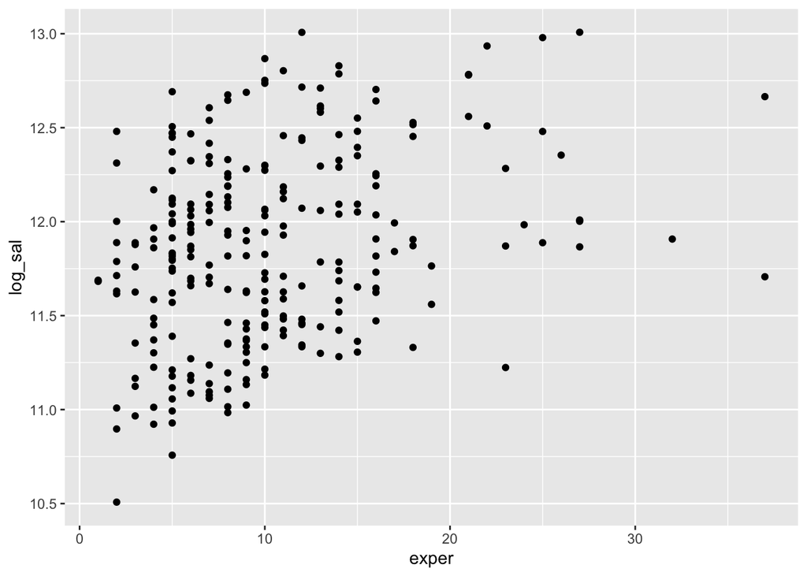

```r
lawsuit_log %>% ggplot(aes(x = exper, y = log_sal)) + geom_point()
```

According to the scatter plot, we decide to split the exper into two categories, with the cutoff 10.

```r
lawsuit_w_exp = lawsuit_log %>% mutate(
  exper_ind = as.factor(ifelse(exper <= 10, "<=10", ">10"))
)

lawsuit_log = lawsuit_log %>% mutate(
  exper_ind = as.factor(ifelse(exper <= 10, "<=10", ">10"))
) %>% dplyr::select(-exper)
```

So we stratified the model based on rank and exper.

## Rank

```r
rank.asso = lm(log_sal ~ ., data = lawsuit_w_exp %>% filter(rank == "Associate") %>% dplyr::select(-rank, - exper_ind) )
rank.full = lm(log_sal ~ ., data = lawsuit_w_exp %>% filter(rank == "Full professor") %>% dplyr::select(-rank, - exper_ind) )
rank.assi = lm(log_sal ~ ., data = lawsuit_w_exp %>% filter(rank == "Assistant") %>% dplyr::select(-rank, - exper_ind) )

summary(rank.asso)
```

```
##
## Call:
## lm(formula = log_sal ~ ., data = lawsuit_w_exp %>% filter(rank ==
##     "Associate") %>% dplyr::select(-rank, -exper_ind))
##
## Residuals:
##       Min        1Q    Median        3Q       Max
## -0.274164 -0.060967  0.003168  0.064316  0.187076
##
## Coefficients:
##                      Estimate Std. Error t value Pr(>|t|)
## (Intercept)         10.941250   0.211266  51.789  < 2e-16 ***
## deptPhysiology      -0.185252   0.044019  -4.208 9.98e-05 ***
## deptGenetics         0.188033   0.060790   3.093 0.003157 **
## deptPediatrics       0.257619   0.085605   3.009 0.004001 **
## deptMedicine         0.547668   0.074601   7.341 1.27e-09 ***
## deptSurgery          0.993195   0.101116   9.822 1.57e-13 ***
## genderMale          -0.006709   0.032397  -0.207 0.836736
## clinClinical         0.257869   0.063616   4.054 0.000166 ***
## certBroad certified  0.201650   0.031978   6.306 5.88e-08 ***
## prate                0.020150   0.027378   0.736 0.464996
## exper                0.021126   0.002682   7.878 1.75e-10 ***
## ---
## Signif. codes:  0 '***' 0.001 '**' 0.01 '*' 0.05 '.' 0.1 ' ' 1
##
## Residual standard error: 0.1037 on 53 degrees of freedom
## Multiple R-squared:  0.9625, Adjusted R-squared:  0.9554
## F-statistic: 135.9 on 10 and 53 DF,  p-value: < 2.2e-16
```

```r
summary(rank.assi)
```

```
##
## Call:
## lm(formula = log_sal ~ ., data = lawsuit_w_exp %>% filter(rank ==
##     "Assistant") %>% dplyr::select(-rank, -exper_ind))
##
## Residuals:
##      Min       1Q   Median       3Q      Max
## -0.31816 -0.08949 -0.01846  0.09748  0.77669
##
## Coefficients:
##                      Estimate Std. Error t value Pr(>|t|)
## (Intercept)         11.344923   0.220750  51.393  < 2e-16 ***
## deptPhysiology      -0.194302   0.062800  -3.094  0.00255 **
## deptGenetics         0.123636   0.069290   1.784  0.07737 .
## deptPediatrics       0.138992   0.092082   1.509  0.13431
## deptMedicine         0.503926   0.080622   6.250 9.86e-09 ***
## deptSurgery          0.794702   0.107236   7.411 3.93e-11 ***
## genderMale           0.069682   0.035682   1.953  0.05361 .
## clinClinical         0.067055   0.074552   0.899  0.37056
## certBroad certified  0.131899   0.040984   3.218  0.00173 **
## prate               -0.052287   0.028846  -1.813  0.07286 .
## exper                0.025830   0.005329   4.847 4.54e-06 ***
## ---
## Signif. codes:  0 '***' 0.001 '**' 0.01 '*' 0.05 '.' 0.1 ' ' 1
##
## Residual standard error: 0.1524 on 101 degrees of freedom
## Multiple R-squared:  0.9153, Adjusted R-squared:  0.907
## F-statistic: 109.2 on 10 and 101 DF,  p-value: < 2.2e-16
```

```r
summary(rank.full)
```

```
##
## Call:
## lm(formula = log_sal ~ ., data = lawsuit_w_exp %>% filter(rank ==
##     "Full professor") %>% dplyr::select(-rank, -exper_ind))
##
## Residuals:
##      Min       1Q   Median       3Q      Max
## -0.27946 -0.07982 -0.00076  0.07518  0.25281
##
## Coefficients:
##                      Estimate Std. Error t value Pr(>|t|)
## (Intercept)         11.259191   0.244832  45.987  < 2e-16 ***
## deptPhysiology      -0.127747   0.039167  -3.262 0.001677 **
## deptGenetics         0.247192   0.065279   3.787 0.000308 ***
## deptPediatrics       0.163201   0.100733   1.620 0.109458
## deptMedicine         0.525148   0.075076   6.995 1.00e-09 ***
## deptSurgery          0.944357   0.103081   9.161 8.25e-14 ***
## genderMale          -0.040854   0.037616  -1.086 0.280973
## clinClinical         0.176401   0.069613   2.534 0.013392 *
## certBroad certified  0.257912   0.034280   7.524 1.03e-10 ***
## prate               -0.001504   0.031555  -0.048 0.962124
## exper                0.014886   0.002288   6.505 8.11e-09 ***
## ---
## Signif. codes:  0 '***' 0.001 '**' 0.01 '*' 0.05 '.' 0.1 ' ' 1
##
## Residual standard error: 0.1172 on 74 degrees of freedom
## Multiple R-squared:  0.9511, Adjusted R-squared:  0.9444
## F-statistic: 143.8 on 10 and 74 DF,  p-value: < 2.2e-16
```

According to the result above, we can see that the variable prate is not significant for every level of rank. Thus, we decide to exclude prate from the stratified model of rank.

## Exper

```r
exper.tenplus = lm(log_sal ~ ., data = lawsuit_log %>% filter(exper_ind == "<=10") %>% dplyr::select( - exper_ind) )
exper.tenminus = lm(log_sal ~ ., data = lawsuit_log %>% filter(exper_ind == ">10") %>% dplyr::select( - exper_ind) )


summary(exper.tenplus)
```

```
##
## Call:
## lm(formula = log_sal ~ ., data = lawsuit_log %>% filter(exper_ind ==
##     "<=10") %>% dplyr::select(-exper_ind))
##
## Residuals:
##      Min       1Q   Median       3Q      Max
## -0.35084 -0.08689 -0.00088  0.07865  0.78307
##
## Coefficients:
##                     Estimate Std. Error t value Pr(>|t|)
## (Intercept)         11.25317    0.17782  63.285  < 2e-16 ***
## deptPhysiology      -0.22958    0.04362  -5.263 4.86e-07 ***
## deptGenetics         0.17649    0.05532   3.190  0.00173 **
## deptPediatrics       0.15899    0.07572   2.100  0.03743 *
## deptMedicine         0.50801    0.06573   7.729 1.49e-12 ***
## deptSurgery          0.86992    0.08811   9.873  < 2e-16 ***
## genderMale           0.05292    0.02619   2.020  0.04516 *
## clinClinical         0.14681    0.05682   2.584  0.01073 *
## certBroad certified  0.16721    0.02967   5.636 8.45e-08 ***
## prate               -0.02293    0.02280  -1.006  0.31621
## rankAssociate        0.17615    0.02867   6.143 7.02e-09 ***
## rankFull professor   0.26694    0.03646   7.321 1.42e-11 ***
## ---
## Signif. codes:  0 '***' 0.001 '**' 0.01 '*' 0.05 '.' 0.1 ' ' 1
##
## Residual standard error: 0.1451 on 149 degrees of freedom
## Multiple R-squared:  0.9186, Adjusted R-squared:  0.9125
## F-statistic: 152.8 on 11 and 149 DF,  p-value: < 2.2e-16
```

```r
summary(exper.tenminus)
```

```
##
## Call:
## lm(formula = log_sal ~ ., data = lawsuit_log %>% filter(exper_ind ==
##     ">10") %>% dplyr::select(-exper_ind))
##
## Residuals:
##      Min       1Q   Median       3Q      Max
## -0.30945 -0.08760  0.00679  0.07938  0.39912
##
## Coefficients:
##                     Estimate Std. Error t value Pr(>|t|)
## (Intercept)         11.11821    0.27182  40.902  < 2e-16 ***
## deptPhysiology      -0.12954    0.04613  -2.808  0.00613 **
## deptGenetics         0.16093    0.06932   2.322  0.02256 *
## deptPediatrics       0.17123    0.09944   1.722  0.08861 .
## deptMedicine         0.51341    0.07940   6.466 5.46e-09 ***
## deptSurgery          0.94398    0.11018   8.568 3.18e-13 ***
## genderMale           0.02438    0.03858   0.632  0.52897
## clinClinical         0.24478    0.07455   3.283  0.00147 **
## certBroad certified  0.25119    0.03792   6.623 2.69e-09 ***
## prate                0.01340    0.03379   0.396  0.69272
## rankAssociate        0.14351    0.05404   2.655  0.00940 **
## rankFull professor   0.25570    0.05043   5.071 2.18e-06 ***
## ---
## Signif. codes:  0 '***' 0.001 '**' 0.01 '*' 0.05 '.' 0.1 ' ' 1
##
## Residual standard error: 0.14 on 88 degrees of freedom
## Multiple R-squared:  0.9258, Adjusted R-squared:  0.9165
## F-statistic: 99.84 on 11 and 88 DF,  p-value: < 2.2e-16
```

According to the result above, we can see that the variable prate is not significant for every level of exper. Thus, we decide to exclude prate from the stratified model of exper.

```r
rank.asso = lm(log_sal ~ . -prate, data = lawsuit_w_exp %>% filter(rank == "Associate") %>% dplyr::select(-rank, - exper_ind) )
rank.full = lm(log_sal ~ .-prate, data = lawsuit_w_exp %>% filter(rank == "Full professor") %>% dplyr::select(-rank, - exper_ind) )
rank.assi = lm(log_sal ~ .-prate, data = lawsuit_w_exp %>% filter(rank == "Assistant") %>% dplyr::select(-rank, - exper_ind) )
exper.tenplus = lm(log_sal ~ .-prate, data = lawsuit_log %>% filter(exper_ind == "<=10") %>% dplyr::select( - exper_ind) )
exper.tenminus = lm(log_sal ~ .-prate, data = lawsuit_log %>% filter(exper_ind == ">10") %>% dplyr::select( - exper_ind) )
```

# Model Diagnostics

## Assumption Check

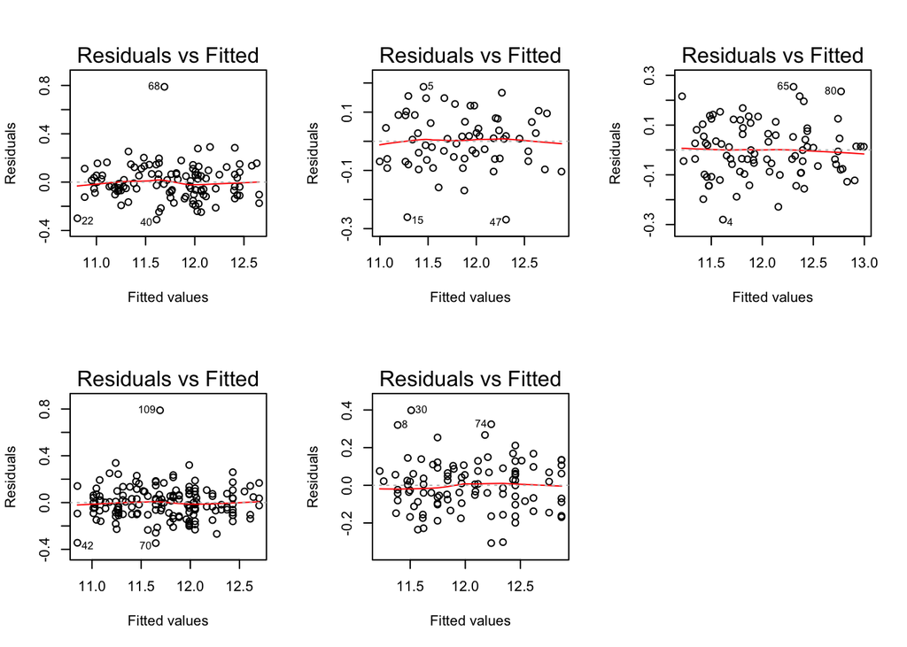

```r
par(mfrow=c(2,3))
plot(rank.assi, which = 1)
plot(rank.asso, which = 1)
plot(rank.full, which = 1)
plot(exper.tenplus, which = 1)
plot(exper.tenminus, which = 1)
```

[figure not shown]

```r
par(mfrow=c(2,3))
plot(rank.assi, which = 2, xlab = "Assistant")
plot(rank.asso, which = 2, xlab = "Association")
plot(rank.full, which = 2, xlab = "Full professor")
plot(exper.tenplus, which = 2, xlab = "More than 10 years")
plot(exper.tenminus, which = 2, xlab = "Less than 10 years")
```

## Multicollinearity

```r
vif.full = vif(rank.full) %>% as.data.frame() %>% rownames_to_column()
names(vif.full) = c("variable", "vif")
vif.full %>% .[which(.$vif > 5),]
```

```
## [1] variable vif
## <0 rows> (or 0-length row.names)
```

```r
vif.asso = vif(rank.asso) %>% as.data.frame() %>% rownames_to_column()
names(vif.asso) = c("variable", "vif")
vif.asso %>% .[which(.$vif > 5),]
```

```
## [1] variable vif
## <0 rows> (or 0-length row.names)
```

```r
vif.assi = vif(rank.assi) %>% as.data.frame() %>% rownames_to_column()
names(vif.assi) = c("variable", "vif")
vif.assi %>% .[which(.$vif > 5),]
```

```
## [1] variable vif
## <0 rows> (or 0-length row.names)
```

```r
vif.tenminus = vif(exper.tenminus) %>% as.data.frame() %>% rownames_to_column()
names(vif.tenminus) = c("variable", "vif")
vif.tenminus %>% .[which(.$vif > 5),]
```

```
## [1] variable vif
## <0 rows> (or 0-length row.names)
```

```r
vif.tenplus = vif(exper.tenplus) %>% as.data.frame() %>% rownames_to_column()
names(vif.tenplus) = c("variable", "vif")
vif.tenplus %>% .[which(.$vif > 5),]
```

```
## [1] variable vif
## <0 rows> (or 0-length row.names)
```

## Functional forms for continuous variables

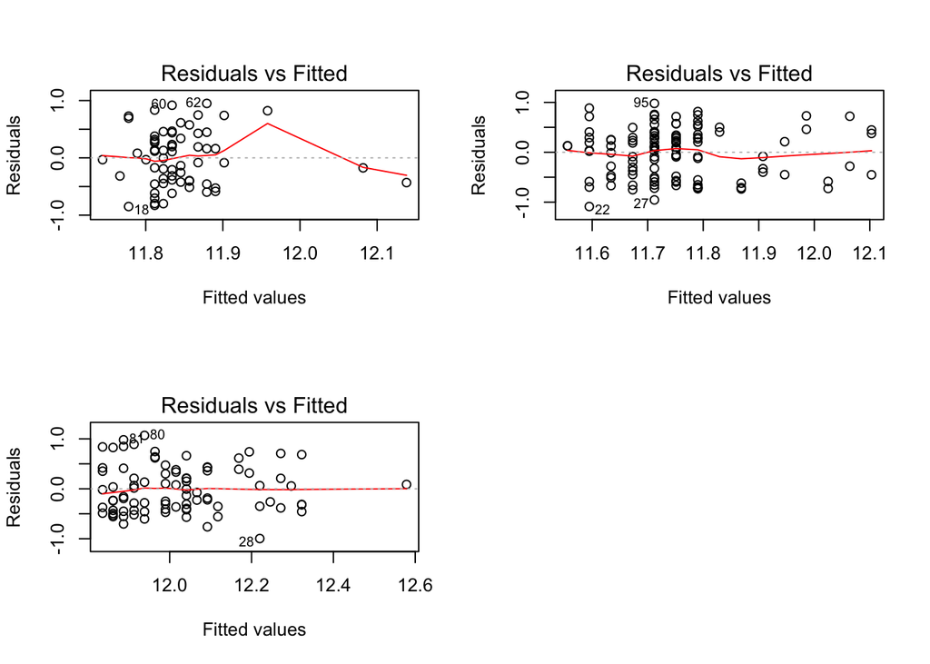

```r
fit1 = lm(log_sal ~ exper, data = lawsuit_w_exp %>% filter(rank == "Associate") %>% dplyr::select(-rank, - exper_ind))
fit2 = lm(log_sal ~ exper, data = lawsuit_w_exp %>% filter(rank == "Assistant") %>% dplyr::select(-rank, - exper_ind))
fit3 = lm(log_sal ~ exper, data = lawsuit_w_exp %>% filter(rank == "Full professor") %>% dplyr::select(-rank, - exper_ind))
par(mfrow=c(2,2))
plot(fit1, which = 1)
plot(fit2, which = 1)
plot(fit3, which = 1)

#lm(log_sal ~ ., data = lawsuit_w_exp %>% filter(rank == "Associate") %>% dplyr::select(-rank, - exper_ind)) %>% summary()

#lm(log_sal ~ . + I(exper^2), data = lawsuit_w_exp %>% filter(rank == "Associate") %>% dplyr::select(-rank, - exper_ind)) %>% summary()
```

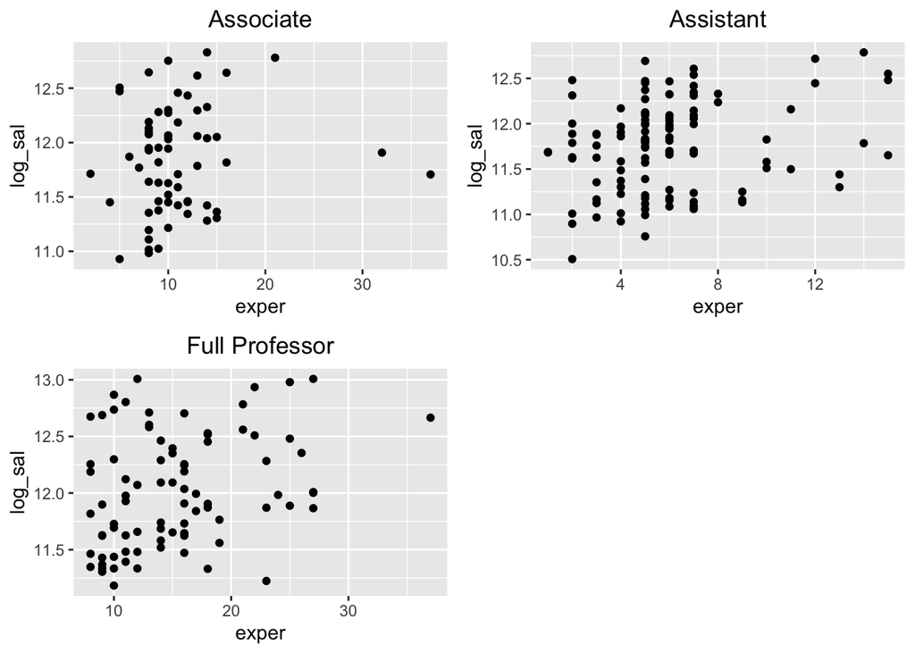

```r
lawsuit_w_exp %>% filter(rank == "Associate") %>% dplyr::select(-rank, - exper_ind) %>% ggplot(aes(x=exper, y = log_sal)) + geom_point() + labs(title = "Associate") + theme(plot.title = element_text(hjust = 0.5))+
lawsuit_w_exp %>% filter(rank == "Assistant") %>% dplyr::select(-rank, - exper_ind) %>% ggplot(aes(x=exper, y = log_sal)) + geom_point()  + labs(title = "Assistant") + theme(plot.title = element_text(hjust = 0.5))+
lawsuit_w_exp %>% filter(rank == "Full professor") %>% dplyr::select(-rank, - exper_ind) %>% ggplot(aes(x=exper, y = log_sal)) + geom_point() + plot_layout(ncol = 2, nrow = 2) + labs(title = "Full Professor") + theme(plot.title = element_text(hjust = 0.5))
```

We can see that for, the residual vs fitted plots does not suggest a curvilinear trend and the scatter plot shows a potenrial increasing linear relationship between exper and outcome. Thus, for continuous variables “exper”, the function form may be linear.

# Outliers/Influential points

## Outliers in Y

```r
rs_full = rstandard(rank.full)
out_y_full = rs_full[abs(rs_full)>2.5]


rs_asso = rstandard(rank.asso)
out_y_asso = rs_asso[abs(rs_asso)>2.5]


rs_assi = rstandard(rank.assi)
out_y_assi = rs_assi[abs(rs_assi)>2.5]


rs_tenplus = rstandard(exper.tenplus)
out_y_tenplus = rs_tenplus[abs(rs_tenplus)>2.5]


rs_tenminus = rstandard(exper.tenminus)
out_y_tenminus = rs_tenminus[abs(rs_tenminus)>2.5]


out_y_full
```

```
## named numeric(0)
```

```r
out_y_asso
```

```
##        15        47
## -2.780400 -2.706451
```

```r
out_y_assi
```

```
##       68
## 5.581751
```

```r
out_y_tenplus
```

```
##      109
## 5.711846
```

```r
out_y_tenminus
```

```
##       30
## 3.055071
```

The data 0 for Full The data 15 and 47 are outliers in Y for associate professor. The data 68 for assitant. The data 109 for ten plus. the data 30 for ten minus.

## Outliers in X

```r
hat_full = lm.influence(rank.full)$hat
hat_asso = lm.influence(rank.asso)$hat
hat_assi = lm.influence(rank.assi)$hat
hat_tenplus = lm.influence(exper.tenplus)$hat
hat_tenminus = lm.influence(exper.tenminus)$hat

hat_full[hat_full>0.2]
```

```
##        40        47        48        49        50        72
## 0.2568140 0.2838955 0.2893311 0.2831800 0.2816270 0.2314687
```

```r
hat_asso[hat_asso>0.2]
```

```
##         8        14        16        24        25        26        27
## 0.4379014 0.2127785 0.3659291 0.2079602 0.2467268 0.3095519 0.2670705
##        28        29        34        38        55        58        63
## 0.2774541 0.2539701 0.2451113 0.2133521 0.2287838 0.2208510 0.2060738
```

```r
hat_assi[hat_assi>0.2]
```

```
##         9
## 0.2042631
```

```r
hat_tenplus[hat_tenplus>0.2]
```

```
## named numeric(0)
```

```r
hat_tenminus[hat_tenminus>0.2]
```

```
##        44        45        49        50        51        52        53
## 0.2035686 0.2090815 0.2544612 0.2079972 0.2305970 0.2426451 0.2131091
##        54        55
## 0.2131091 0.2592421
```

The data 40, 47, 48, 49, 50, 72 for full The data 8,14,16,24,25,26,27,28,29,34,38,55,58,63 for asso The data 9 for assi The data 0 for ten plus The data 44, 45, 49, 50, 51, 52, 53, 54, 55 for tenminus

## Influential point

### Dffits

```r
dffits_full = dffits(rank.full)
n_full = nrow(lawsuit_log %>% filter(rank == "Full professor"))

dffits_asso = dffits(rank.asso)
n_asso = nrow(lawsuit_log %>% filter(rank == "Associate"))

dffits_assi = dffits(rank.assi)
n_assi = nrow(lawsuit_log %>% filter(rank == "Assistant"))

dffits_tenplus = dffits(exper.tenplus)
n_tenplus = nrow(lawsuit_log %>% filter(rank == ">10"))

dffits_tenminus = dffits(exper.tenminus)
n_tenminus = nrow(lawsuit_log %>% filter(rank == "<=10"))



a = abs(dffits_full[c(40, 47, 48, 49, 50, 72)]) > sqrt(7/n_full)*2
a[a==TRUE]
```

```
##   47
## TRUE
```

```r
a= abs(dffits_asso[c(8,14,16,24,25,26,27,28,29,34,38,55,58,63,15,47)]) > sqrt(7/n_asso)*2
a[a==TRUE]
```

```
##    8   16   24   29   38   15   47
## TRUE TRUE TRUE TRUE TRUE TRUE TRUE
```

```r
a = abs(dffits_assi[c(9,68)]) > sqrt(7/n_assi)*2
a[a==TRUE]
```

```
##   68
## TRUE
```

```r
a = abs(dffits_tenplus[c(109)]) > sqrt(7/n_tenplus)*2
a[a==TRUE]
```

```
## named logical(0)
```

```r
a = abs(dffits_tenminus[c(44, 45, 49, 50, 51, 52, 53, 54, 55, 39)]) > sqrt(7/n_tenminus)*2
a[a==TRUE]
```

```
## named logical(0)
```

For full, 47 is influential. For asso, 8, 16, 24, 29, 38,15,47. For assi, 68

```r
a = cooks.distance(rank.full)[c(40, 47, 48, 49, 50, 72)] >  (4/n_full)
a[a==T]
```

```
##   47
## TRUE
```

```r
a = cooks.distance(rank.asso)[c(8,14,16,24,25,26,27,28,29,34,38,55,58,63,15,47)] > (4/n_asso)
a[a==T]
```

```
##    8   16   24   29   38   15
## TRUE TRUE TRUE TRUE TRUE TRUE
```

```r
a = cooks.distance(rank.assi)[c(9,68)] > (4/n_assi)
a[a==T]
```

```
##   68
## TRUE
```

```r
a = cooks.distance(exper.tenplus)[c(109)] > (4/n_tenplus)
a[a==T]
```

```
## named logical(0)
```

```r
a = cooks.distance(exper.tenminus)[c(44, 45, 49, 50, 51, 52, 53, 54, 55, 39)] > (4/n_tenminus)
a[a==T]
```

```
## named logical(0)
```

The cook’s distance:

For full, 47 is influential. For asso, 8, 16, 24, 29, 38,15 For assi, 68

## Removing influential points

```r
rank.asso_no = lm(log_sal ~ . -prate, data = lawsuit_w_exp %>% filter(rank == "Associate") %>% dplyr::select(-rank, - exper_ind) %>% .[c(-8, -16, -24, -29, -38,-15, -47),] )
rank.full_no = lm(log_sal ~ .-prate, data = lawsuit_w_exp %>% filter(rank == "Full professor") %>% dplyr::select(-rank, - exper_ind) %>% .[c(-47),] )
rank.assi_no = lm(log_sal ~ .-prate, data = lawsuit_w_exp %>% filter(rank == "Assistant") %>% dplyr::select(-rank, - exper_ind) %>% .[-68,] )
```

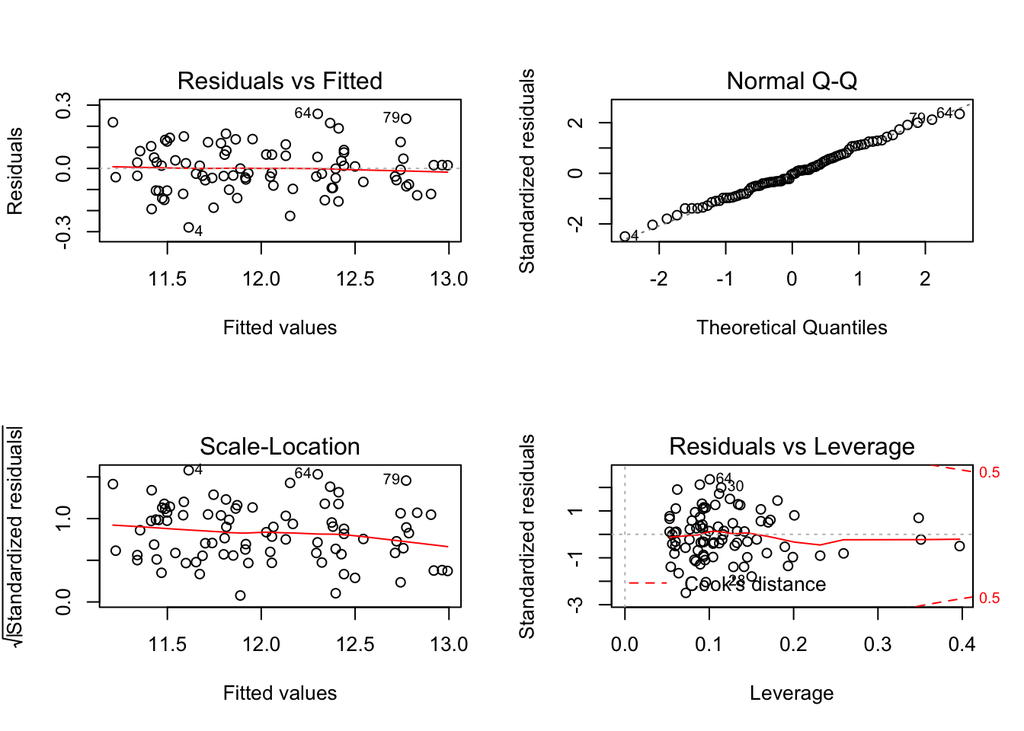

```r
par(mfrow = c(2,2))
plot(rank.full_no)
```

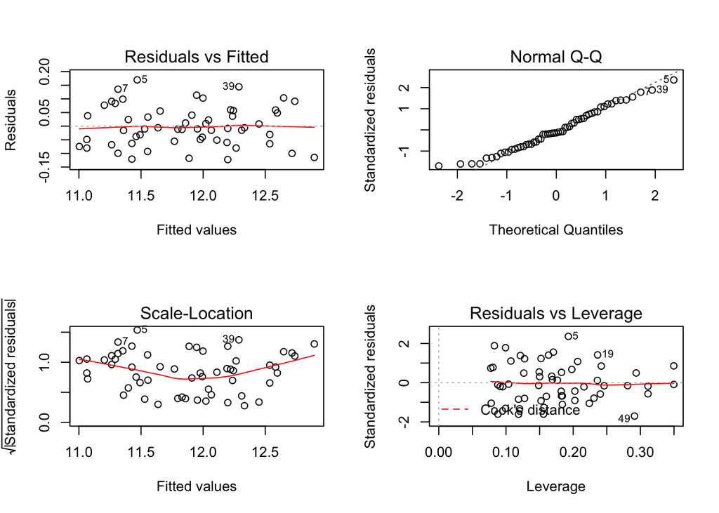

```r
par(mfrow = c(2,2))
plot(rank.asso_no)
```

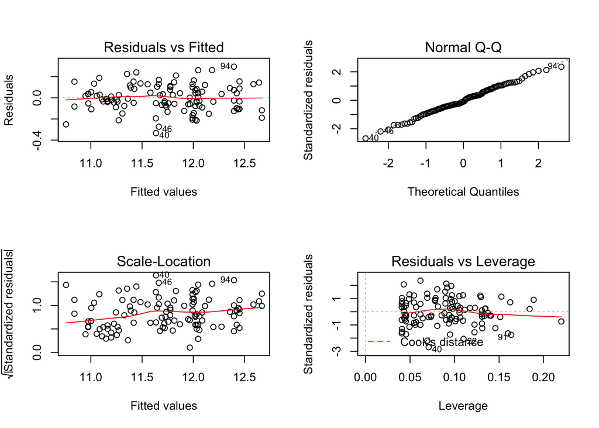

```r
par(mfrow = c(2,2))
plot(rank.assi_no)
```